| title: “Intro_to_longpca_with_nycflights_data” |
| --- |
| output: rmarkdown::html_vignette |
| vignette: > |
| % |
| % |
| % |

## Introduction

If you’ve already read the readme, you can skip to PCA the nycflights

This package introduces a novel formula syntax for PCA. In modern applications (where data is often in “long format”), the formula syntax helps to fluidly imagine PCA without thinking about matrices. In other words, it provides a layer of abstraction above matrices. Given the formula and the (long) data, the code in this package transforms your data into a proper format for fast PCA via sparse linear algebra. The package also provides code to 1) help pick the number of dimensions to compute, 2) diagnose the suitability of PCA (both pre and post PCA), 3) rotate the PCs with varimax, 4) visualize and interpret the dimensions uncovered, and (not yet) 5) make predictions. This package uses “PCA” as a broad term for computing the leading singular vectors of a normalized (sometimes incomplete) matrix. Some might refer to specific instances as factor analysis, correspondence analysis, latent symantic analysis, social network analysis, or low-rank matrix completion, among other possible terms. This is big-tent PCA, all included. `longpca` is in development. So, functions and syntax might change.

The current approach to PCA (principal components analysis) is *matrix first*. This note begins to explore an alternative path, one that is *model first*. The formula syntax provides an alternative way to think about PCA that makes matrices transparent; completely hidden, unless you want to see the code.

I hope this makes PCA legible for folks that have not yet learned linear algebra (just like linear models are legible without solving linear systems of equations).

I am personally inspired by this approach because (despite the fact that I love matrices and linear algebra) I find that this *model first* way of thinking is so much easier and more direct.

This document gives an illustration with a data analysis of the popular `nycflights13` data via PCA. Headline: we find two seasonal effects (annual and weekly) and also the “fly-over-zone” (midwest 4ever. ride or die <3 much love to my midwest fam). Code details follow this analysis.

(Disclaimer: this is very early in this project. So, the syntax and the code is likely to change a great deal. Input is very welcome about ways to improve it.)

#### Install

The functions for PCA for the People are contained in an R package `longpca`. If you do not already have `devtools` installed, you will first need to install that:

```r
install.packages("devtools")
devtools::install_github("karlrohe/longpca")
```

Thank you to Alex Hayes for helpful feedback in this process and suggesting the name `longpca`.

### PCA the nycflights.

The code is fast and nimble:

```r
library(nycflights13)
pcs = pca_count(~ (month & day)*(dest),
                flights,
                k = 6)
```

This performs PCA. The key innovation is the “formula”:

`~ (month & day)*(dest)`,

which specifies the model that we want (i.e. the matrix for PCA). In particular, it will perform PCA on a matrix where the rows are indexed by `(month & day)`, two variables of the `flights` data. There are 365 unique values of these. And the columns of the matrix are indexed by destinations `dest`, another variable in `flights`. There are about 100 different destinations. There are multiple rows of `flights` with identical values of `month & day` and `dest` (e.g. lots of flights from LGA -> LAX every day); the function `pca_count` fills the elements of the matrix by counting the number of flights on each day to each destination.

A similar function `pca_sum` allows for a variable on the left hand side of the formula and it populates the elements of the matrix by summing up the values. For example, `nycflights13` has the number of seats available in each plane. We can join this data to the flights to find the number of seats available on each flight.

```r
dat = flights %>%
  select(month, day, dest, tailnum) %>%
  left_join(planes %>% select(tailnum, seats))
```

If we use the formula `seats ~(month & day)*dest` inside `pca_sum`, then it will perform PCA on a matrix where the elements correspond to the total number of seats that flew to each destination, on each day.

```r
pcs_seats = pca_sum(seats ~(month & day)*dest, dat, 6)
```

The output contains the pc’s and their loadings in a tidy format:

```r
pcs$row_features %>% sample_n(size = 3)
```

```
#> # A tibble: 3 × 12
#>   month   day     n row_num degree weighted_degree pc_1_rows pc_2_rows pc_3_rows
#>   <int> <int> <int>   <int>  <int>           <dbl>     <dbl>     <dbl>     <dbl>
#> 1     4     5   981     111     85             981      1.04    -0.775     0.837
#> 2     7    25  1003       7     86            1003      1.04     1.04     -0.118
#> 3    10     8   964     185     85             964      1.03     1.07      0.654
#> # ℹ 3 more variables: pc_4_rows <dbl>, pc_5_rows <dbl>, pc_6_rows <dbl>
```

```r
pcs$column_features %>% sample_n(size = 3)
```

```
#> # A tibble: 3 × 11
#>   dest      n col_num degree weighted_degree pc_1_columns pc_2_columns
#>   <chr> <int>   <int>  <int>           <dbl>        <dbl>        <dbl>
#> 1 SMF     284      84    284             284        0.282        0.437
#> 2 DCA    9705      10    365            9705        1.74        -0.338
#> 3 HOU    2115      44    365            2115        0.812        0.733
#> # ℹ 4 more variables: pc_3_columns <dbl>, pc_4_columns <dbl>,
#> #   pc_5_columns <dbl>, pc_6_columns <dbl>
```

Because they are tidy, it makes them pretty easy to ggplot.

First, let’s do the rows (i.e. dates). To interpret pc’s, it is best to plot it with contextual information and/or in the *native space*. For dates, the native space is a time series or a sequence. Let’s plot it there. I give my interpretation after the plots.

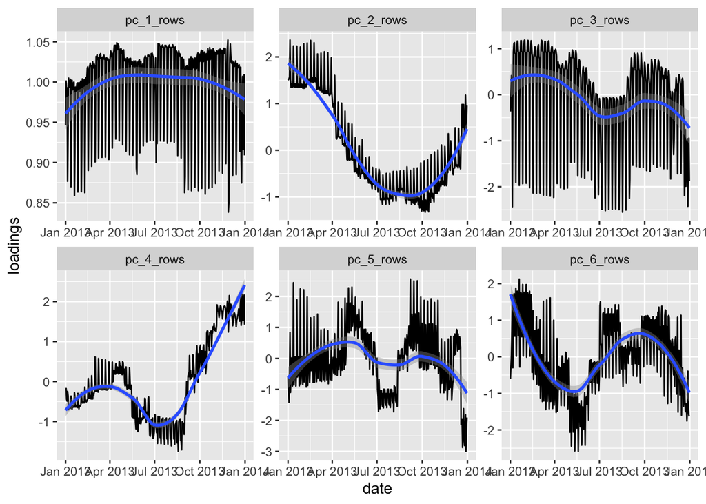

```r
pcs = pca_count(1 ~ (month & day)*(dest), flights, k = 6)

pcs$row_features %>%
  mutate(date = make_date(day = day, month=month, year = 2013)) %>%
  select(date, contains("pc_")) %>%
  pivot_longer(contains("pc_"), names_to = "pc_dimension", values_to = "loadings") %>%
  ggplot(aes(x = date, y = loadings)) + geom_line() +
  facet_wrap(~pc_dimension, scales= "free") + geom_smooth()
```

Now, let’s do the columns (i.e. destinations). The “native space” for destinations is a map. Let’s plot it there. Be sure you have `maps` installed.

```r
airports %>% sample_n(size = 3)
```

```
#> # A tibble: 3 × 8
#>   faa   name                          lat    lon   alt    tz dst   tzone
#>   <chr> <chr>                       <dbl>  <dbl> <dbl> <dbl> <chr> <chr>
#> 1 EMK   Emmonak Airport              62.8 -164.     13    -9 A     America/Anch…
#> 2 LCQ   Lake City Municipal Airport  30.2  -82.6   201    -5 A     America/New_…
#> 3 KLN   Larsen Bay Airport           57.5 -154.     87    -9 A     America/Anch…
```

```r
# first, get the lat and lon for the airports:
airport_dat = pcs$column_features %>%
  left_join(airports %>% select(dest=faa, lat,lon)) %>%
  select(lat, lon, contains("_col")) %>%
  pivot_longer(contains("pc_"),
               names_to = "pc_dimension", values_to = "loadings") %>%
  drop_na()
```

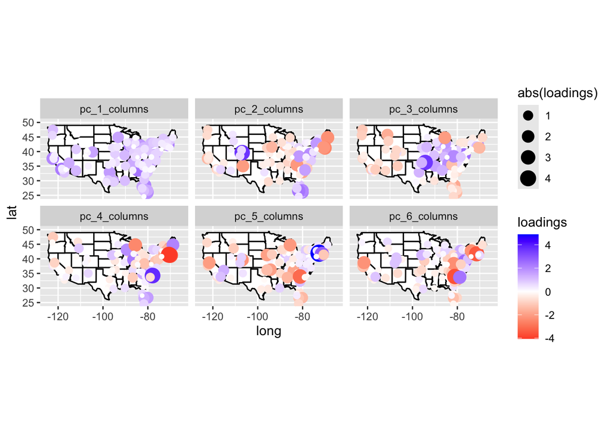

```r
library(maps)
usa_map <- map_data("state")
p <- ggplot() +
  geom_polygon(data = usa_map, aes(x = long, y = lat, group = group),
               fill = "white", color = "black") +
  coord_fixed(1.3, xlim = c(-125, -65), ylim = c(25, 50))
# i'm only keeping lower 48 states, dropping Anchorage and Honolulu.


p + geom_point(data = airport_dat, aes(x = lon, y = lat,
                                       size = abs(loadings), color = loadings)) +
  facet_wrap(~ pc_dimension)  +
  scale_color_gradient2(low = "red", high = "blue", mid = "white")
```

So, using the code is easy. You just need to specify a formula. It’s fun to think of other combinations and easy to try them out.

There are three functions that you might like `diagnose`, `pick_dim`, and `plot` that are explained below.

# A deeper look inside the code.

To illustrate the code, consider the popular data example `nycflights13` which contains a row for every flight departing from the 3 main New York City airports during 2013 (LGA, JFK, and EWR). It includes things like date, destination, and information about delays.

```r
library(nycflights13)
flights
```

```
#> # A tibble: 336,776 × 19
#>     year month   day dep_time sched_dep_time dep_delay arr_time sched_arr_time
#>    <int> <int> <int>    <int>          <int>     <dbl>    <int>          <int>
#>  1  2013     1     1      517            515         2      830            819
#>  2  2013     1     1      533            529         4      850            830
#>  3  2013     1     1      542            540         2      923            850
#>  4  2013     1     1      544            545        -1     1004           1022
#>  5  2013     1     1      554            600        -6      812            837
#>  6  2013     1     1      554            558        -4      740            728
#>  7  2013     1     1      555            600        -5      913            854
#>  8  2013     1     1      557            600        -3      709            723
#>  9  2013     1     1      557            600        -3      838            846
#> 10  2013     1     1      558            600        -2      753            745
#> # ℹ 336,766 more rows
#> # ℹ 11 more variables: arr_delay <dbl>, carrier <chr>, flight <int>,
#> #   tailnum <chr>, origin <chr>, dest <chr>, air_time <dbl>, distance <dbl>,
#> #   hour <dbl>, minute <dbl>, time_hour <dttm>
```

There are so many matrices “inside” of this data, but you don’t think of them when you see this data. Many applications are like this. The data does not look like matrix. Instead, it looks like a spreadsheet or a SQL database or a tibble. That is how the users think about their data. *And underneath it*, there are so many possible matrices.

## A formula to make the matrix transparent

For example, in the flights example, you could make a matrix where every row is a day of the year and every column is a destination airport. Each element of the matrix is the number of flights to that destination on that day. To do that, we propose using a formula, like in `lm`.

```r
formula = 1 ~ (month & day)*(dest)
```

This formula and the flights data will make a sparse matrix. The left-hand side is `1` to denote we are just going to count the occurrences over the 336,776 rows of `flights`. If there was another column (e.g. `size`) for which it was sensible to sum multiple values (e.g. number of people on the flight, or number of gallons of fuel consumed), then you could do that with `size ~ (month & day)*(dest)`. On the right hand side, there is an “interaction” in the parlance of linear models and the notation of `lm`. The first terms in the interaction will index the rows of a matrix. Here, there are two columns of `flights`, in particular `month & day`. There are 365 unique combinations of these values. Each will be a row. The second term in the interaction does the same thing, but those terms will become the columns.

All suggestions welcome for the formula syntax. Maybe it should also allow `(month & day) ~ dest`? Maybe the ampersand `&` is confusing and another symbol would be better? Other thoughts? Relevant footnote: the syntax should also allow low-rank matrix completion, e.g. predicting arrival delay: `arr_delay ~ (month & day)*(dest)`.

# Model first, not matrix first.

To make maximum use of this package, it is helpful to think about *models*, not *matrices*. This will become clearer as time goes on. Each of the key functions in this package is handling a class `interaction_model`:

```r
im = make_interaction_model(flights, formula)
im
```

```
#> $row_universe
#> # A tibble: 365 × 4
#>    month   day     n row_num
#>    <int> <int> <int>   <int>
#>  1    11    27  1014       1
#>  2     7    11  1006       2
#>  3     7     8  1004       3
#>  4     7    10  1004       4
#>  5    12     2  1004       5
#>  6     7    18  1003       6
#>  7     7    25  1003       7
#>  8     7    12  1002       8
#>  9     7     9  1001       9
#> 10     7    17  1001      10
#> # ℹ 355 more rows
#>
#> $column_universe
#> # A tibble: 105 × 3
#>    dest      n col_num
#>    <chr> <int>   <int>
#>  1 ORD   17283       1
#>  2 ATL   17215       2
#>  3 LAX   16174       3
#>  4 BOS   15508       4
#>  5 MCO   14082       5
#>  6 CLT   14064       6
#>  7 SFO   13331       7
#>  8 FLL   12055       8
#>  9 MIA   11728       9
#> 10 DCA    9705      10
#> # ℹ 95 more rows
```

`im` is a list of four elements. First, `$interaction_tibble` which can be thought of as a sparse matrix in triplet form; `get_Matrix(im)` uses this to construct a sparse matrix. Then, `$row_universe` and `$column_universe` which can be thought of as holding the information corresponding to each row/column. Finally, `$settings` contains various details about the construction.

This function has an argument `parse_text` that uses `tidytext::unnest_tokens` to construct “document-term interaction models”. More on this later.

# Let’s do the analysis

### Examining the matrix sparsity

This package contains a few helper functions. First, if lots of rows or columns have very few non-zero elements, this can cause “localization issues”. The matrix needs to be “dense enough” for the PCA to find good stuff. So, `diagnose` prints some simple diagnostics and plots the “degree distribution” for the rows and columns. Here, “degree” is the number of non-zero elements in that row or column.

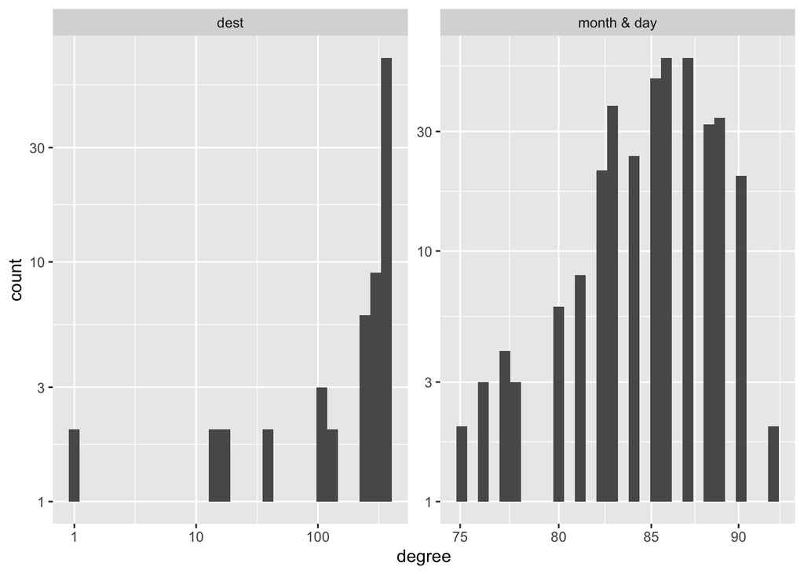

```
#> # A tibble: 6 × 3
#>   measurement      dest `month & day`
#>   <chr>           <dbl>         <dbl>
#> 1 number_of_items   105           365
#> 2 average_degree    297            86
#> 3 median_degree     365            86
#> 4 percent_le_1        2             0
#> 5 percent_le_2        2             0
#> 6 percent_le_3        2             0
```

```r
# inspect "degree distributions" with this funciton:
#  recall that im is the interaction_model defined above.
diagnose(im)
```

For example, if either average degree was less than 10, then I might be worried. `percent_le_x` gives the percent of rows/columns that have row/col sums less than or equal to `x`. If these values are large, then the matrix is very sparse and you might have trouble. Issues with sparsity will likely manifest in localization; something that will be evaluated in functions below.

### Picking k with cross-validated eigenvalues

When doing a PCA, you need to pick the number of dimensions that you want. The way that we do this in my lab is with cross-validated eigenvalues. It gives you a Z-score and a p-value. [Here is the arxiv paper](https://arxiv.org/abs/2108.03336). Alex Hayes made it a proper R package on CRAN [gdim](https://cran.r-project.org/web/packages/gdim/gdim.pdf). For this example, it picks `k=4`.

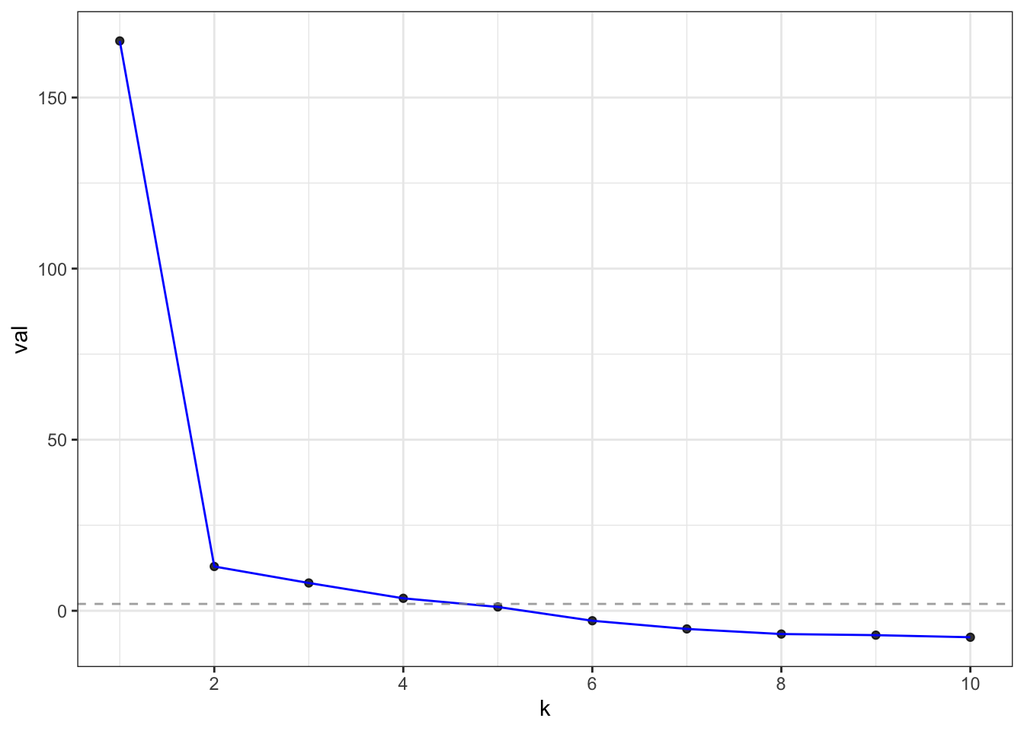

```r
cv_eigs = pick_dim(im, dimMax = 10,num_bootstraps = 5)
plot(cv_eigs)
```

```r
cv_eigs
```

```
#> Estimated graph dimension:    4
#>
#> Number of bootstraps:         5
#> Edge splitting probabaility:  0.1
#> Significance level:       0.05
#>
#>  ------------ Summary of Tests ------------
#>   k          z        pvals         padj
#>   1 166.537817 0.000000e+00 0.000000e+00
#>   2  12.940218 1.334364e-38 1.334364e-38
#>   3   8.122732 2.279022e-16 2.279022e-16
#>   4   3.640859 1.358651e-04 1.358651e-04
#>   5   1.119370 1.314912e-01 1.314912e-01
#>   6  -2.913897 9.982153e-01 9.982153e-01
#>   7  -5.306554 9.999999e-01 9.999999e-01
#>   8  -6.800637 1.000000e+00 1.000000e+00
#>   9  -7.125141 1.000000e+00 1.000000e+00
#>  10  -7.738070 1.000000e+00 1.000000e+00
```

Notice that the top-line of the printout says that the estimated graph dimension is 4. So, we will use `k=6` and see that in this example they become harder to interpret. This is what we would expect if it was just noise… but also, maybe they are not just noise?

### Let’s get the people some PCA

For right now, I named the function `pca_count`, because if there are multiple rows of the data that have the same values for `(month & day)` and also for `dest`, then the value inside the matrix is a *sum* of the values on the left hand side of the formula. Right now, that is just `1`. So, it *counts* how many times that entry appears. Some people call this a cross-tab or a contingency table. When we do PCA to this matrix of counts, some folks call that Correspondence Analysis.

```r
pcs = pca_count(formula, tib = flights, k = 6)

# There are two other ways to accomplish the same thing:
pcs_with_sum = pca_sum(formula, tib = flights, k = 6)
# or directly with the interaction_model object via the function pca:
pcs_with_im = pca(im, k = 6)
```

In particular, the code takes a square root of every count. Then, computes the normalized and regularized Laplacian `L` (using the number of non-zero entries as the degree). Then, computes the leading `k` singular vectors. This is all done with sparse linear algebra via the packages `Matrix` and `irlba`.

```r
names(pcs)
```

```
#> [1] "row_features"    "column_features" "middle_B"        "settings"
```

The `row_features` and `column_features` are the PC’s and loadings (I don’t prefer those old terms). `middle_B` gives the singular values. `settings` contains some details that are handy in later functions.

```r
sample_n(pcs$row_features, size = 3)
```

```
#> # A tibble: 3 × 12
#>   month   day     n row_num degree weighted_degree pc_1_rows pc_2_rows pc_3_rows
#>   <int> <int> <int>   <int>  <int>           <dbl>     <dbl>     <dbl>     <dbl>
#> 1     1     7   933     223     86             933      1.00    -1.35    -0.924
#> 2     8     1  1000      17     86            1000      1.04     0.969    0.138
#> 3     7    16   996      32     85             996      1.04     1.03     0.0827
#> # ℹ 3 more variables: pc_4_rows <dbl>, pc_5_rows <dbl>, pc_6_rows <dbl>
```

```r
sample_n(pcs$column_features, size=3)
```

```
#> # A tibble: 3 × 11
#>   dest      n col_num degree weighted_degree pc_1_columns pc_2_columns
#>   <chr> <int>   <int>  <int>           <dbl>        <dbl>        <dbl>
#> 1 TVC     101      93     37             101       0.0745        0.753
#> 2 IND    2077      45    365            2077       0.798         0.499
#> 3 GRR     765      65    349             765       0.478        -0.493
#> # ℹ 4 more variables: pc_3_columns <dbl>, pc_4_columns <dbl>,
#> #   pc_5_columns <dbl>, pc_6_columns <dbl>
```

Notice that these features are in a wide and tidy form, making it easy to `lubridate::make_date` (for `row_features`) and left-join with airports (to get latitude and longitude) for `column_features`.

##### Diagnostic plots

You can `plot(pcs)`. It makes these five plots, each described after all plots are displayed.

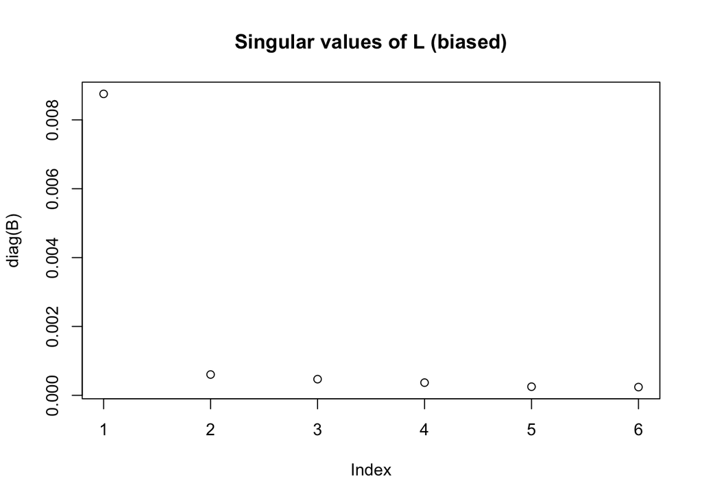

```
#> Press [Enter] to continue to the next plot...
```

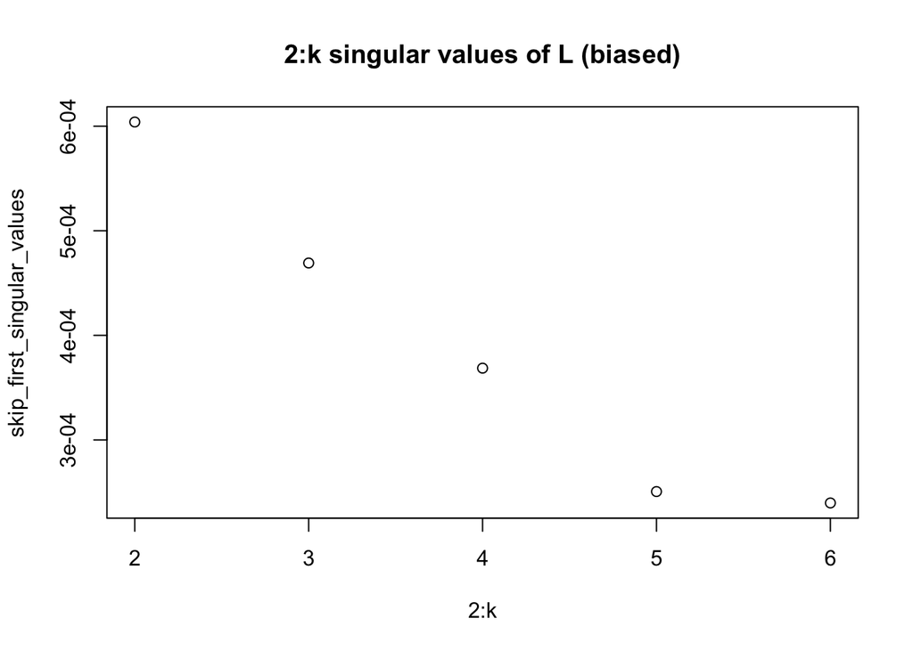

```
#> Press [Enter] to continue to the next plot...
```

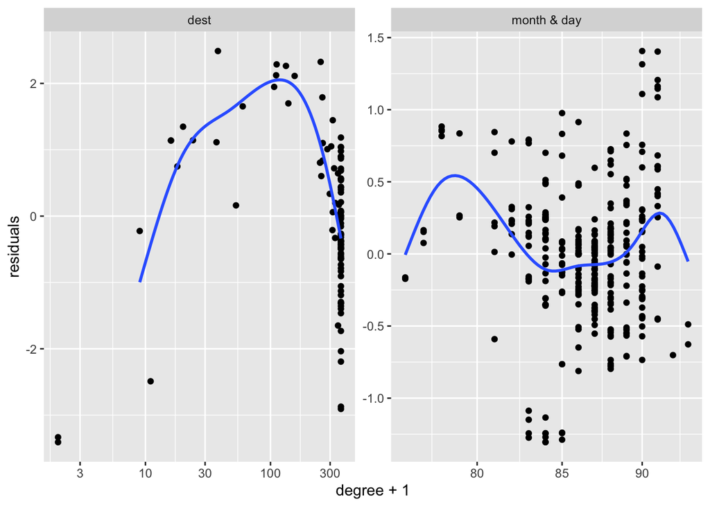

```
#> Press [Enter] to continue to the next plot...
```

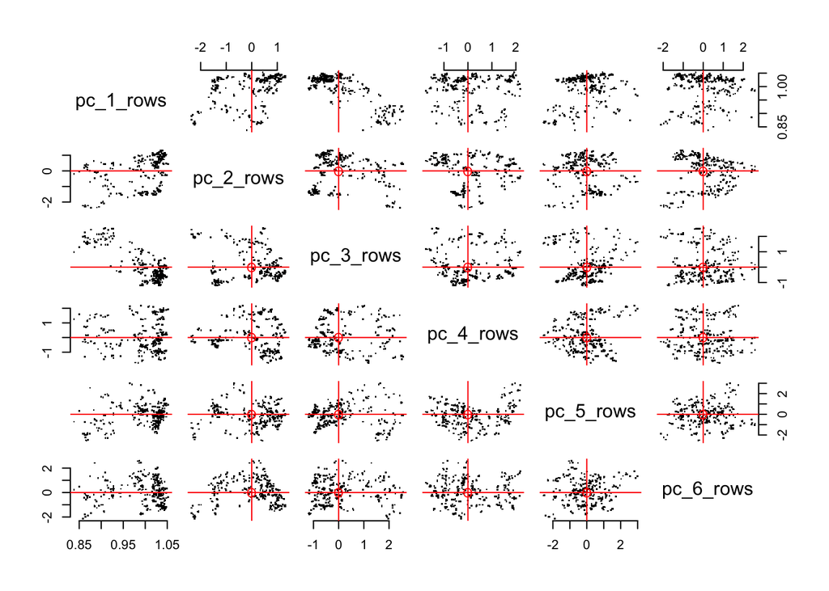

```
#> Press [Enter] to continue to the next plot...
```

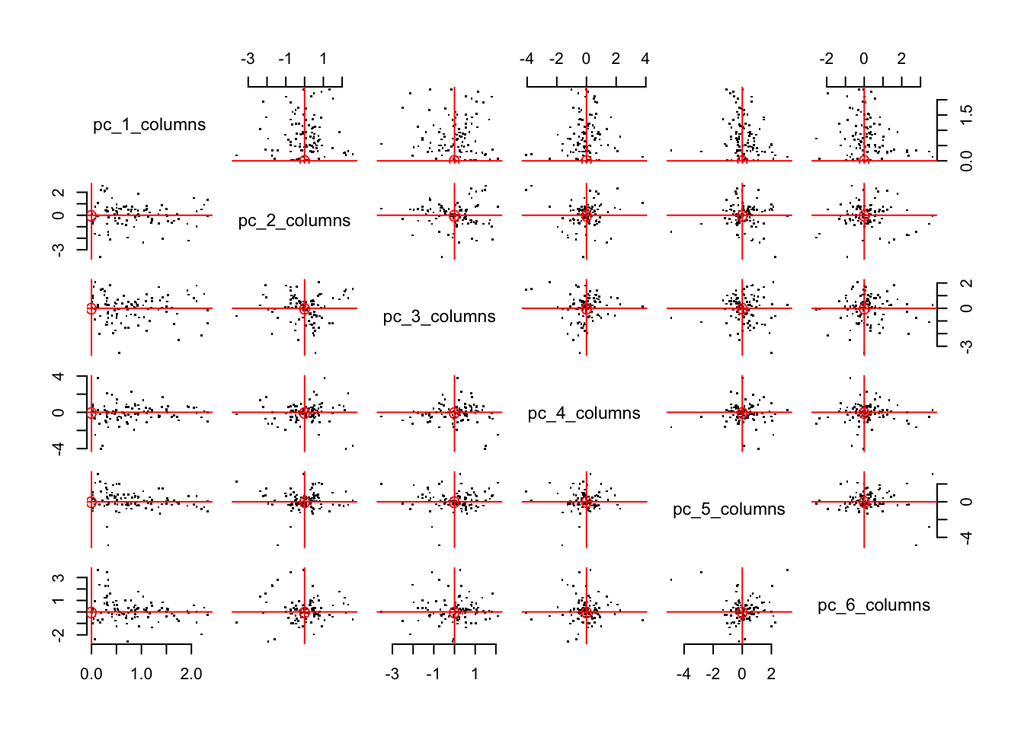

```r
plot(pcs)
```

These are the five plots:

1. Screeplot: The top `k` singular values of `L`.
2. Better screeplot: its singular values `2:k` (because the first one is usually dominant and difficult to see an elbow past it).
3. A “localization plot” which is very similar (maybe exact?) to [this stuff](https://github.com/karlrohe/LocalizationDiagnostic); for each row (and column) compute its degree and its leverage score. Take the log of both. Fit a linear model `log(leverage)~log(degree)` and plot the residuals against `log(degree)`. If there is localization, I suspect that there will be a big curl on the right side.
4. Pairs plot of `row_features`. This is the plot emphasized in the varimax paper. In these example plots below, we do not see very clear radial streaks.
5. A pairs plot for `column_features`. In both pairs plots, if there are more than 1000 points, then the code samples 1000 points with probability proportional to their leverage scores. It will plot up to `k=10` dimensions. If `k` is larger, then it plots the first 5 and the last 5.